# Machine Learning - Course Project

HLC

## 1. Executive Summary

Using devices such as Jawbone Up, Nike FuelBand, and Fitbit it is now possible to collect a large amount of data about personal activity relatively inexpensively. These type of devices are part of the quantified self movement - a group of enthusiasts who take measurements about themselves regularly to improve their health, to find patterns in their behavior, or because they are tech geeks. One thing that people regularly do is quantify how much of a particular activity they do, but they rarely quantify how well they do it. In this project, we will use data from accelerometers on the belt, forearm, arm, and dumbell of 6 participants. They were asked to perform barbell lifts correctly and incorrectly in 5 different ways. More information is available from the website here: http://groupware.les.inf.puc-rio.br/har (see the section on the Weight Lifting Exercise Dataset).

The goal of this project is to predict the manner in which the group did the exercise. This is the “classe” variable in the training set. We will use 39 variables to predict with, and detail how to build the best model, cross validation, sample error and why the model is best choice. We will also use the prediction model to predict 20 different test cases.

## 2. Exploration Data Analysis

- The training data for this project are available for download from this link: [plm-training](https://d396qusza40orc.cloudfront.net/predmachlearn/pml-training.csv)
- The test data for this project are available for download from this link: [pml-testing](https://d396qusza40orc.cloudfront.net/predmachlearn/pml-testing.csv)

```r
# Set seed to allow reproducible results
set.seed(6789)
# Data in training set containing Null and "DIV/0!" values will be replaced with "NA".
# Load the training dataset and replace Null and "DIV/0!" with "NA"
train.dataset <- read.csv("~/MOOC/Machine_Learning/pml-training.csv", na.strings=c("NA","#DIV/0!", ""))

# Data in test set containing Null and "DIV/0!" values will be replaced with "NA".
# Load the testing dataset and replace Null and "DIV/0!" with "NA"
test.dataset <- read.csv('~/MOOC/Machine_Learning/pml-testing.csv', na.strings=c("NA","#DIV/0!", ""))

# Check size of training and test dataset
dim(train.dataset)
```

```
## [1] 19622   160
```

```r
dim(test.dataset)
```

```
## [1]  20 160
```

## 3. Cleaning up Dataset for Analysis

```r
# Remove colums with all NA values
train.dataset<-train.dataset[,colSums(is.na(train.dataset)) == 0]
test.dataset <-test.dataset[,colSums(is.na(test.dataset)) == 0]
```

### Cleaning up of column dataset

In column 1 to column 7, the variables under columns “X”, “user_name”, “raw_timestamp_part1”, “raw_timestamp_part2”, “cvdt_timestamp”, “new_window” and “num_window” are not highly significant in predicting the “Classe” variable of the dataset. Hence we remove the irrelevant column variables from both training and testing dataset.

```r
# We remove columns 1 -7 as it is not required for the training and test dataset. Theere are 53 columns remaining in the dataset.
train.dataset <-train.dataset[,c(8:60)]
test.dataset <-test.dataset[,c(8:60)]
```

## 4 Remove all high correlation variables

```r
# Calculating the Correlation
cor_train_matrix <- cor(na.omit(train.dataset[sapply(train.dataset, is.numeric)]))
```

```r
# Remove all high correlation which are more than 80%.
rm_cor_train <- findCorrelation(cor_train_matrix, cutoff = .80, verbose = TRUE)
```

```
## Compare row 10  and column  1 with corr  0.992
##   Means:  0.27 vs 0.168 so flagging column 10
## Compare row 1  and column  9 with corr  0.925
##   Means:  0.25 vs 0.164 so flagging column 1
## Compare row 9  and column  4 with corr  0.928
##   Means:  0.233 vs 0.161 so flagging column 9
## Compare row 36  and column  29 with corr  0.849
##   Means:  0.251 vs 0.158 so flagging column 36
## Compare row 8  and column  2 with corr  0.966
##   Means:  0.239 vs 0.154 so flagging column 8
## Compare row 2  and column  11 with corr  0.884
##   Means:  0.221 vs 0.15 so flagging column 2
## Compare row 21  and column  24 with corr  0.814
##   Means:  0.194 vs 0.149 so flagging column 21
## Compare row 34  and column  28 with corr  0.808
##   Means:  0.185 vs 0.146 so flagging column 34
## Compare row 25  and column  26 with corr  0.814
##   Means:  0.154 vs 0.145 so flagging column 25
## Compare row 19  and column  18 with corr  0.918
##   Means:  0.096 vs 0.146 so flagging column 18
## Compare row 46  and column  45 with corr  0.846
##   Means:  0.11 vs 0.149 so flagging column 45
## Compare row 46  and column  31 with corr  0.914
##   Means:  0.091 vs 0.152 so flagging column 31
## Compare row 46  and column  33 with corr  0.933
##   Means:  0.07 vs 0.156 so flagging column 33
## All correlations <= 0.8
```

```r
training_dataset <- train.dataset[,-rm_cor_train]
dim(training_dataset)
```

```
## [1] 19622    40
```

```r
unique(training_dataset$classe)
```

```
## [1] A B C D E
## Levels: A B C D E
```

After cleaning of training dataset, we now have 19622 samples with 40 column vaiables. This training_dataset will be used to build our prediction model.

## 5 Preparing to split the dataset for training and testing

```r
# Next we will split dataset 70% for training and 30% for testing.
part.tr <- createDataPartition(y = training_dataset$classe, p=0.7,list=FALSE)
part.training <- training_dataset[part.tr,]
part.testing <- training_dataset[-part.tr,]

dim(part.training)
```

```
## [1] 13737    40
```

```r
dim(part.testing)
```

```
## [1] 5885   40
```

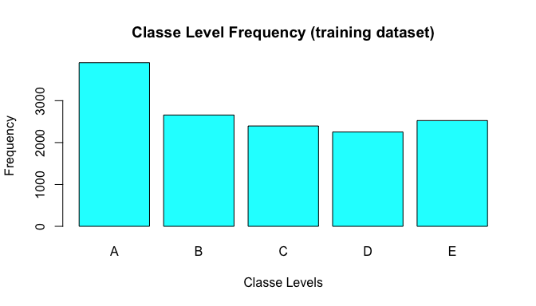

```r
# Plot the Levels of the variable classe in the training dataset
plot(part.training$classe, col=5, main="Classe Level Frequency (training dataset)",
     xlab="Classe Levels", ylab= "Frequency")
```

## 7 Fitting the Model Selection

```r
# Perform Decision Tree model
fit.model.tree <- train(classe ~ .,method = "rpart",data = part.training)
# Perform Linear Discriminant Analysis model
fit.model.lda <-train(classe ~ ., method = 'lda',data = part.training)
# Perform Random forest model. This train model will take more than 60 minutes depending on your hardware for training process.
fit.model.rf <- train(classe ~ .,  method = 'rf',data = part.training)

# Print result using Random Forest
print(fit.model.rf)
```

```
## Random Forest
##
## 13737 samples
##    39 predictor
##     5 classes: 'A', 'B', 'C', 'D', 'E'
##
## No pre-processing
## Resampling: Bootstrapped (25 reps)
## Summary of sample sizes: 13737, 13737, 13737, 13737, 13737, 13737, ...
## Resampling results across tuning parameters:
##
##   mtry  Accuracy   Kappa      Accuracy SD  Kappa SD
##    2    0.9866494  0.9831065  0.002194270  0.002780434
##   20    0.9875804  0.9842853  0.002138834  0.002711385
##   39    0.9774306  0.9714404  0.005219385  0.006616462
##
## Accuracy was used to select the optimal model using  the largest value.
## The final value used for the model was mtry = 20.
```

## 8 Cross validation check

Although the Random Forest model seems to produce the best result, but we still need to perform cross validation also to prevent overfitting of our final model. The goal of cross-validation is to define a data set to “test” the model in the training phase in order to limit overfitting and give an insight on how the model will generalize to test data set.

We will use K-fold cross-validation to perform this analysis. Taking into account the data size (about 13,737 observations), the number of fold is set to 5 for calculation performance while maintaining an acceptable level of bias. We use caret package’s train() function. Cross-validation will be performed with method set to ‘cv’ and the number of folds is set to 5 to train the model.

```r
# Perform Random forest model. This train model will take more than 20 minutes depending on your hardware for training process.
k.fit.model.rf <- train(classe ~ .,  method = 'rf',data=part.training,
                        trControl = trainControl(method="cv",number=5, allowParallel = TRUE) )
print(k.fit.model.rf)
```

```
## Random Forest
##
## 13737 samples
##    39 predictor
##     5 classes: 'A', 'B', 'C', 'D', 'E'
##
## No pre-processing
## Resampling: Cross-Validated (5 fold)
## Summary of sample sizes: 10989, 10990, 10989, 10990, 10990
## Resampling results across tuning parameters:
##
##   mtry  Accuracy   Kappa      Accuracy SD  Kappa SD
##    2    0.9890808  0.9861851  0.002136499  0.002702526
##   20    0.9895176  0.9867378  0.001879014  0.002377994
##   39    0.9830387  0.9785412  0.002474695  0.003129939
##
## Accuracy was used to select the optimal model using  the largest value.
## The final value used for the model was mtry = 20.
```

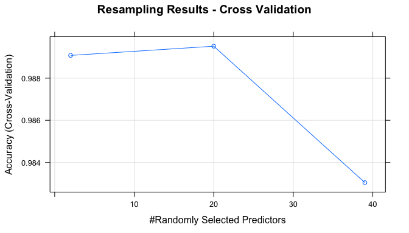

```r
#Plot Resampling Results - Cross Validation.
plot(k.fit.model.rf, main="Resampling Results - Cross Validation")
```

## 9 Prediction using testing data

```r
#Using our best fit model to predict on test dataset
prediction_randomforest <- predict(k.fit.model.rf, part.testing)
confusionMatrix(part.testing$classe, prediction_randomforest)
```

```
## Confusion Matrix and Statistics
##
##           Reference
## Prediction    A    B    C    D    E
##          A 1673    1    0    0    0
##          B   15 1119    5    0    0
##          C    0   12 1007    7    0
##          D    0    0   12  950    2
##          E    0    0    0    4 1078
##
## Overall Statistics
##
##                Accuracy : 0.9901
##                  95% CI : (0.9873, 0.9925)
##     No Information Rate : 0.2868
##     P-Value [Acc > NIR] : < 2.2e-16
##
##                   Kappa : 0.9875
##  Mcnemar's Test P-Value : NA
##
## Statistics by Class:
##
##                      Class: A Class: B Class: C Class: D Class: E
## Sensitivity            0.9911   0.9885   0.9834   0.9886   0.9981
## Specificity            0.9998   0.9958   0.9961   0.9972   0.9992
## Pos Pred Value         0.9994   0.9824   0.9815   0.9855   0.9963
## Neg Pred Value         0.9964   0.9973   0.9965   0.9978   0.9996
## Prevalence             0.2868   0.1924   0.1740   0.1633   0.1835
## Detection Rate         0.2843   0.1901   0.1711   0.1614   0.1832
## Detection Prevalence   0.2845   0.1935   0.1743   0.1638   0.1839
## Balanced Accuracy      0.9954   0.9922   0.9897   0.9929   0.9987
```

## 10 Determine the accuracy of prediction

```r
postResample(prediction_randomforest, part.testing$classe)
```

```
##  Accuracy     Kappa
## 0.9901444 0.9875302
```

### Expected out of sample error result

We noted the accuracy of predictions is up to 99%. Hence the expected out of sample error is 1%.

## 11 Using best model to predict 20 observations in test dataset provided

The Random Forest Model (after fine tuning with cross validation) is used to predict 20 test observations in the test data provided in the project.

```r
prediction_result <- predict(k.fit.model.rf, test.dataset)
print(prediction_result)
```

```
##  [1] B A B A A E D B A A B C B A E E A B B B
## Levels: A B C D E
```

## Appendix-1.1

### Results of Decision Tree model

```r
print(fit.model.tree)
```

```
## CART
##
## 13737 samples
##    39 predictor
##     5 classes: 'A', 'B', 'C', 'D', 'E'
##
## No pre-processing
## Resampling: Bootstrapped (25 reps)
## Summary of sample sizes: 13737, 13737, 13737, 13737, 13737, 13737, ...
## Resampling results across tuning parameters:
##
##   cp          Accuracy   Kappa       Accuracy SD  Kappa SD
##   0.03173634  0.5173513  0.38197390  0.02508567   0.04196388
##   0.03255010  0.5131209  0.37642510  0.02674648   0.04442989
##   0.06604109  0.3279009  0.07450807  0.08300149   0.13534468
##
## Accuracy was used to select the optimal model using  the largest value.
## The final value used for the model was cp = 0.03173634.
```

### Results of Linear Discriminant Analysis model

```r
print(fit.model.lda)
```

```
## Linear Discriminant Analysis
##
## 13737 samples
##    39 predictor
##     5 classes: 'A', 'B', 'C', 'D', 'E'
##
## No pre-processing
## Resampling: Bootstrapped (25 reps)
## Summary of sample sizes: 13737, 13737, 13737, 13737, 13737, 13737, ...
## Resampling results
##
##   Accuracy   Kappa      Accuracy SD  Kappa SD
##   0.6425728  0.5484223  0.006094948  0.007447639
##
##
```

## Appendix-1.2

### Create Function pml_write_files

```r
pml_write_files = function(x){
    n = length(x)
    for(i in 1:n){
        filename = paste0("problem_id_",i,".txt")
        write.table(x[i],file=filename,quote=FALSE,row.names=FALSE,col.names=FALSE)
    }
}
```

### Predicting on 20 test cases using our prediction model. It will generate 20 text files at working directory(~~/MOOC/Machine_Learning)

```r
prediction_result <- predict(k.fit.model.rf, test.dataset);
print(prediction_result);
```

```
##  [1] B A B A A E D B A A B C B A E E A B B B
## Levels: A B C D E
```

```r
#Write result to 20 text files
pml_write_files(as.vector(prediction_result))
```